# Análise exploratória de sequências CDR3

Primeira iteração

Matheus Cardoso

Jun 18, 2020

# 1 Introdução

Nesse documento será feita uma análise explotarória dos dados advindos do software `attila`.

# 2 Métodos

## 2.1 Processamento dos dados

Para começar a análise, eu carrego os dados de um arquivo binário que foi previamente salvo. Esse arquivo `rds` foi gerado por um script em `R` que está no meu [fork](https://github.com/Cardosaum/attila/blob/master/programs/cdr/tmp.R) do `attila`.

A baixo apresento um resumo do dataframe.

```r
library(tidyverse)
library(magrittr)

cdr <- read_rds("./data/binary/isaura_compressed.rds")
cdr %<>% mutate(type = factor(case_when(
                        str_detect(file, "Final") ~ "final",
                        str_detect(file, "Initial") ~ "initial"))) %>%
         ungroup() %>%
         group_by(file) %>%
         mutate(cdrp = quantity/sum(quantity)) %>%
         select(cdr3, type, cdrp, everything()) %>%
         arrange(-cdrp, -quantity) %>%
         ungroup()

dim(cdr)
```

```
## [1] 846376     40
```

```r
names(cdr)
```

```
##  [1] "cdr3"      "type"      "cdrp"      "quantity"  "length"    "MW"
##  [7] "AV"        "IP"        "flex"      "gravy"     "SSF_Helix" "SSF_Turn"
## [13] "SSF_Sheet" "n_A"       "n_C"       "n_D"       "n_E"       "n_F"
## [19] "n_G"       "n_H"       "n_I"       "n_K"       "n_L"       "n_M"
## [25] "n_N"       "n_P"       "n_Q"       "n_R"       "n_S"       "n_T"
## [31] "n_V"       "n_W"       "n_Y"       "aliphatic" "aromatic"  "neutral"
## [37] "positive"  "negative"  "invalid"   "file"
```

```r
knitr::kable(head(cdr))
```

| cdr3 | type | cdrp | quantity | length | MW | AV | IP | flex | gravy | SSF_Helix | SSF_Turn | SSF_Sheet | n_A | n_C | n_D | n_E | n_F | n_G | n_H | n_I | n_K | n_L | n_M | n_N | n_P | n_Q | n_R | n_S | n_T | … |
| --- | --- | --- | --- | --- | --- | --- | --- | --- | --- | --- | --- | --- | --- | --- | --- | --- | --- | --- | --- | --- | --- | --- | --- | --- | --- | --- | --- | --- | --- | --- |
| GEESEIFGVVKY | initial | 1.0000000 | 1 | 12 | 1356.4761 | 0.1667 | 4.2527 | 0.7529 | -0.1333 | 0.4167 | 0.25 | 0.2500 | 0 | 0 | 0 | 3 | 1 | 2 | 0 | 1 | 1 | 0 | 0 | 0 | 0 | 0 | 0 | 1 | 0 | … |
| GEESEIFGVVKY | initial | 1.0000000 | 1 | 12 | 1356.4761 | 0.1667 | 4.2527 | 0.7529 | -0.1333 | 0.4167 | 0.25 | 0.2500 | 0 | 0 | 0 | 3 | 1 | 2 | 0 | 1 | 1 | 0 | 0 | 0 | 0 | 0 | 0 | 1 | 0 | … |
| FLVEVK | final | 0.9629992 | 714166 | 6 | 733.8950 | 0.1667 | 6.0014 | 0.7018 | 1.2667 | 0.6667 | 0.00 | 0.3333 | 0 | 0 | 0 | 1 | 1 | 0 | 0 | 0 | 1 | 1 | 0 | 0 | 0 | 0 | 0 | 0 | 0 | … |
| FLVEVK | final | 0.7156274 | 254505 | 6 | 733.8950 | 0.1667 | 6.0014 | 0.7018 | 1.2667 | 0.6667 | 0.00 | 0.3333 | 0 | 0 | 0 | 1 | 1 | 0 | 0 | 0 | 1 | 1 | 0 | 0 | 0 | 0 | 0 | 0 | 0 | … |
| DGVAVAGLDY | final | 0.7025474 | 6481 | 10 | 979.0413 | 0.1000 | 4.0500 | 0.7231 | 0.6700 | 0.4000 | 0.20 | 0.3000 | 2 | 0 | 2 | 0 | 0 | 2 | 0 | 0 | 0 | 1 | 0 | 0 | 0 | 0 | 0 | 0 | 0 | … |
| DGVAVAGLDY | final | 0.7025474 | 6481 | 10 | 979.0413 | 0.1000 | 4.0500 | 0.7231 | 0.6700 | 0.4000 | 0.20 | 0.3000 | 2 | 0 | 2 | 0 | 0 | 2 | 0 | 0 | 0 | 1 | 0 | 0 | 0 | 0 | 0 | 0 | 0 | … |

```r
summary(cdr)
```

```
##      cdr3                type             cdrp             quantity
##  Length:846376      final  : 82769   Min.   :1.30e-06   Min.   :     1.0
##  Class :character   initial:763607   1st Qu.:2.60e-06   1st Qu.:     1.0
##  Mode  :character                    Median :7.90e-06   Median :     1.0
##                                      Mean   :7.44e-05   Mean   :    10.8
##                                      3rd Qu.:3.07e-05   3rd Qu.:     4.0
##                                      Max.   :1.00e+00   Max.   :714166.0
##      length            MW                AV               IP
##  Min.   : 1.00   Min.   :  75.07   Min.   :0.0000   Min.   : 4.050
##  1st Qu.:10.00   1st Qu.:1078.18   1st Qu.:0.1364   1st Qu.: 4.050
##  Median :12.00   Median :1365.55   Median :0.2143   Median : 4.197
##  Mean   :12.06   Mean   :1391.10   Mean   :0.2200   Mean   : 4.983
##  3rd Qu.:14.00   3rd Qu.:1664.78   3rd Qu.:0.3000   3rd Qu.: 5.567
##  Max.   :32.00   Max.   :3702.13   Max.   :1.0000   Max.   :12.000
##       flex            gravy           SSF_Helix         SSF_Turn
##  Min.   :0.5670   Min.   :-4.5000   Min.   :0.0000   Min.   :0.0000
##  1st Qu.:0.7237   1st Qu.:-1.1583   1st Qu.:0.2667   1st Qu.:0.2000
##  Median :0.7437   Median :-0.6789   Median :0.3333   Median :0.2857
##  Mean   :0.7439   Mean   :-0.6256   Mean   :0.3464   Mean   :0.2961
##  3rd Qu.:0.7637   3rd Qu.:-0.1357   3rd Qu.:0.4286   3rd Qu.:0.3846
##  Max.   :0.9110   Max.   : 4.5000   Max.   :1.0000   Max.   :1.0000
##    SSF_Sheet           n_A             n_C               n_D
##  Min.   :0.0000   Min.   :0.000   Min.   :0.00000   Min.   :0.000
##  1st Qu.:0.0714   1st Qu.:0.000   1st Qu.:0.00000   1st Qu.:1.000
##  Median :0.1333   Median :0.000   Median :0.00000   Median :1.000
##  Mean   :0.1501   Mean   :0.657   Mean   :0.02241   Mean   :1.516
##  3rd Qu.:0.2222   3rd Qu.:1.000   3rd Qu.:0.00000   3rd Qu.:2.000
##  Max.   :1.0000   Max.   :6.000   Max.   :2.00000   Max.   :8.000
##       n_E              n_F              n_G             n_H
##  Min.   :0.0000   Min.   :0.0000   Min.   :0.000   Min.   :0.0000
##  1st Qu.:0.0000   1st Qu.:0.0000   1st Qu.:1.000   1st Qu.:0.0000
##  Median :0.0000   Median :1.0000   Median :2.000   Median :0.0000
##  Mean   :0.3984   Mean   :0.6725   Mean   :1.632   Mean   :0.2009
##  3rd Qu.:1.0000   3rd Qu.:1.0000   3rd Qu.:2.000   3rd Qu.:0.0000
##  Max.   :6.0000   Max.   :5.0000   Max.   :8.000   Max.   :4.0000
##       n_I              n_K              n_L             n_M
##  Min.   :0.0000   Min.   :0.0000   Min.   :0.000   Min.   :0.0000
##  1st Qu.:0.0000   1st Qu.:0.0000   1st Qu.:0.000   1st Qu.:0.0000
##  Median :0.0000   Median :0.0000   Median :0.000   Median :0.0000
##  Mean   :0.3133   Mean   :0.1378   Mean   :0.549   Mean   :0.1766
```

[output cut: 15 more lines]

```
##  Max.   :8.000   Max.   :6.0000   Max.   :7.0000   Max.   :4.0000
##       n_Y           aliphatic         aromatic         neutral
##  Min.   : 0.000   Min.   : 0.000   Min.   : 0.000   Min.   : 0.000
##  1st Qu.: 1.000   1st Qu.: 3.000   1st Qu.: 1.000   1st Qu.: 1.000
##  Median : 1.000   Median : 4.000   Median : 2.000   Median : 2.000
##  Mean   : 1.645   Mean   : 4.563   Mean   : 2.716   Mean   : 1.994
##  3rd Qu.: 2.000   3rd Qu.: 6.000   3rd Qu.: 4.000   3rd Qu.: 3.000
##  Max.   :11.000   Max.   :17.000   Max.   :14.000   Max.   :10.000
##     positive         negative        invalid      file
##  Min.   :0.0000   Min.   :0.000   Min.   :0   Length:846376
##  1st Qu.:0.0000   1st Qu.:1.000   1st Qu.:0   Class :character
##  Median :1.0000   Median :2.000   Median :0   Mode  :character
##  Mean   :0.8717   Mean   :1.914   Mean   :0
##  3rd Qu.:1.0000   3rd Qu.:3.000   3rd Qu.:0
##  Max.   :7.0000   Max.   :9.000   Max.   :0
```

### 2.1.1 Isolando apenas as sequências CDR3 enriquecidas

Como é possível perceber pelos dados acima mostrados, temos muitas reads no dataframe. Entretanto, nosso interesse por agora é nas sequências que foram enriquecidas após várias etapas de seleção. Para isso, nós precisaremos criar um subset do dataframe inicial, contendo apenas CDR3s que apresentam alto percentual de predominância em seu respectivo arquivo de leitura.

Vou mostrar um exemplo do que quero dizer:

```r
cdr %>%
      select(cdr3, type, cdrp, quantity, file) %>%
      head() -> exemplo_unico_cdr

knitr::kable(exemplo_unico_cdr)
```

| cdr3 | type | cdrp | quantity | file |
| --- | --- | --- | --- | --- |
| GEESEIFGVVKY | initial | 1.0000000 | 1 | mariajac_isaura_2_2_isaura_H_0eX4g_L_0bX4c_VH_InitialRound_VLR02b_S9_L001_R1_001aafreq.csv |
| GEESEIFGVVKY | initial | 1.0000000 | 1 | mariajac_isaura_2_2_isaura_H_0eX4h_L_0bX4d_VH_InitialRound_VLR02b_S9_L001_R1_001aafreq.csv |
| FLVEVK | final | 0.9629992 | 714166 | mariajac_Isaura_Pd2_140819_R0xR5_b_VH_FinalRound_R5b_VH_S10_L001_R1_001aafreq.csv |
| FLVEVK | final | 0.7156274 | 254505 | mariajac_Isaura_Pd2_140819_R0xR4_b_VH_FinalRound_R4b_VH_S9_L001_R1_001aafreq.csv |
| DGVAVAGLDY | final | 0.7025474 | 6481 | mariajac_anteriores_isaura_1_isaura_HR01eXHR41h_LR01aXLR41c_VH_FinalRound_VHR41h_S7_L001_R1_001aafreq.csv |
| DGVAVAGLDY | final | 0.7025474 | 6481 | mariajac_anteriores_isaura_1_isaura_HR01eXHR41h_LR01aXLR41d_VH_FinalRound_VHR41h_S7_L001_R1_001aafreq.csv |

Como é possível observar, nas duas primeras linhas temos uma mesma sequência, que apresenta um percentual de 100% predôminancia em seu respectivo arquivo de leiura. (coluna `cdrp` - cdr percentage, variando de 0 a 1). Porém, observamos também que a mesma sequência aparece nesse arquivo somente uma vez. Ou seja, esses dois primeiros arquivos contém só uma leitura, e, portanto, seu percentual de predominância será de 100%. Isso, por outro lado, não reflete enriquecimento de CDR3, e, portanto, nós precisamos remover esses casos.

Pensando em como fazer a seleção dessas sequências enriquecidas, fiz algumas análises:

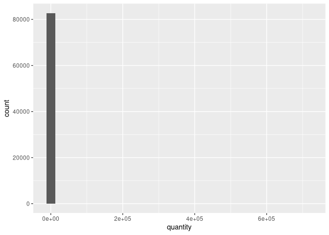

```r
ggplot(filter(cdr, type == "final")) +
  geom_histogram(aes(quantity))
```

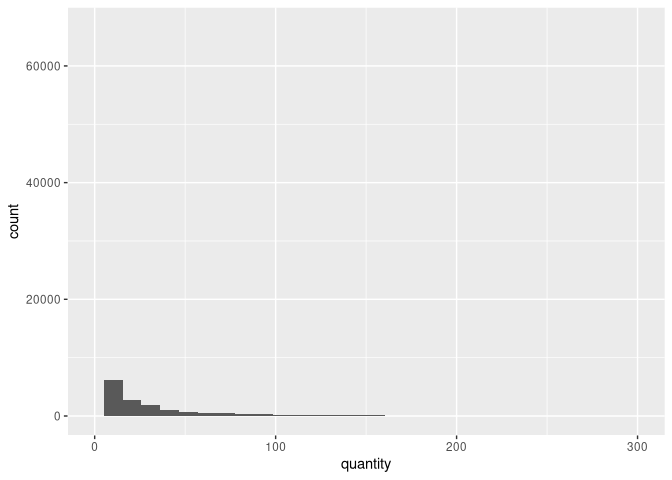

```r
ggplot(filter(cdr, type == "final")) +
  geom_histogram(aes(quantity)) +
  xlim(0, 300)
```

```r
cdr %>%
        filter(type == "final") %>%
        mutate(level = case_when(
                  quantity <= 300 ~ "quantity <= 300",
                  TRUE ~ "quantity > 300")) %>%
        group_by(level) %>%
        summarise("Number of CDR3 sequences" = n()) -> cdr_quantity_comparison_1

knitr::kable(cdr_quantity_comparison_1)
```

| level | Number of CDR3 sequences |
| --- | --- |
| quantity <= 300 | 82055 |
| quantity > 300 | 714 |

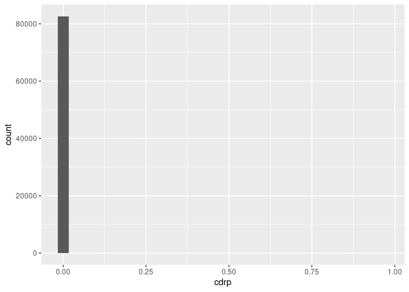

```r
ggplot(filter(cdr, type == "final")) +
  geom_histogram(aes(cdrp))
```

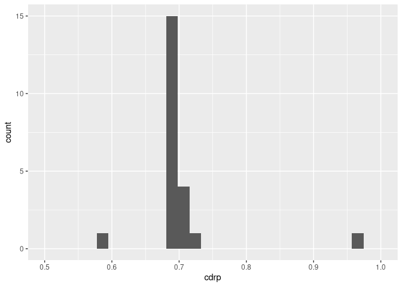

```r
ggplot(filter(cdr, type == "final")) +
  geom_histogram(aes(cdrp)) +
  xlim(0.5, 1)
```

```r
cdr %>%
        filter(type == "final") %>%
        mutate(level = case_when(
                  cdrp <= 0.3 ~ "cdrp <= 0.3",
                  TRUE ~ "cdrp > 0.3")) %>%
        group_by(level) %>%
        summarise("Percentage" = n()) -> cdr_cdrp_comparison_1

knitr::kable(cdr_cdrp_comparison_1, caption = "Percentage of prevalence of CDR3 sequence")
```

Percentage of prevalence of CDR3 sequence

| level | Percentage |
| --- | --- |
| cdrp <= 0.3 | 82746 |
| cdrp > 0.3 | 23 |

```r
cdr %>%
        filter(type == "final") %>%
        mutate(level = case_when(
                  cdrp < 0.5 ~ "cdrp < 0.5",
                  TRUE ~ "cdrp > 0.5")) %>%
        group_by(level) %>%
        summarise("Percentage" = n()) -> cdr_cdrp_comparison_2

knitr::kable(cdr_cdrp_comparison_2, caption = "Percentage of prevalence of CDR3 sequence")
```

Percentage of prevalence of CDR3 sequence

| level | Percentage |
| --- | --- |
| cdrp < 0.5 | 82747 |
| cdrp > 0.5 | 22 |

Como é possível notar, temos 23 sequências de CDR3 que apresentam prevalência maior que 30% em arquivos de leitura individual, e 22 se considerarmos 50% de prevalência.

Para termos noção do que isso significa, vejamos o seguinte:

```r
cdr$file %>% unique() %>% length() -> total_arquivos_leitura

filter(cdr, type == "final")$file %>% unique() %>% length() -> total_arquivos_leitura_final_read

tibble(
  "Arquivo de leitura" = c("Todos (Inicial + Final)", "Apenas Final", "Final com CDR3 prevalência >= 50%"),
  "Quantidade de Arquivos" = c(total_arquivos_leitura, total_arquivos_leitura_final_read, cdr_cdrp_comparison_2$Percentage[2])
) %>% knitr::kable()
```

| Arquivo de leitura | Quantidade de Arquivos |
| --- | --- |
| Todos (Inicial + Final) | 63 |
| Apenas Final | 31 |
| Final com CDR3 prevalência >= 50% | 22 |

E, para mostrar todos os arquivos com prevalência maior que 50%:

```r
cdr %>%
        filter(type == "final" & cdrp >= 0.5) %>%
        select(cdr3, cdrp, quantity, file) %>%
        knitr::kable()
```

| cdr3 | cdrp | quantity | file |
| --- | --- | --- | --- |
| FLVEVK | 0.9629992 | 714166 | mariajac_Isaura_Pd2_140819_R0xR5_b_VH_FinalRound_R5b_VH_S10_L001_R1_001aafreq.csv |
| FLVEVK | 0.7156274 | 254505 | mariajac_Isaura_Pd2_140819_R0xR4_b_VH_FinalRound_R4b_VH_S9_L001_R1_001aafreq.csv |
| DGVAVAGLDY | 0.7025474 | 6481 | mariajac_anteriores_isaura_1_isaura_HR01eXHR41h_LR01aXLR41c_VH_FinalRound_VHR41h_S7_L001_R1_001aafreq.csv |
| DGVAVAGLDY | 0.7025474 | 6481 | mariajac_anteriores_isaura_1_isaura_HR01eXHR41h_LR01aXLR41d_VH_FinalRound_VHR41h_S7_L001_R1_001aafreq.csv |
| DGVAVAGLDY | 0.7025474 | 6481 | mariajac_anteriores_isaura_1_isaura_HR01eXHR41h_LR01bXLR41c_VH_FinalRound_VHR41h_S7_L001_R1_001aafreq.csv |
| DGVAVAGLDY | 0.7025474 | 6481 | mariajac_anteriores_isaura_1_isaura_HR01eXHR41h_LR01bXLR41d_VH_FinalRound_VHR41h_S7_L001_R1_001aafreq.csv |
| DGVAVAGLDY | 0.6955451 | 11866 | mariajac_anteriores_isaura_1_isaura_HR01eXHR41g_LR01aXLR41c_VH_FinalRound_VHR41g_S6_L001_R1_001aafreq.csv |
| DGVAVAGLDY | 0.6955451 | 11866 | mariajac_anteriores_isaura_1_isaura_HR01eXHR41g_LR01aXLR41d_VH_FinalRound_VHR41g_S6_L001_R1_001aafreq.csv |
| DGVAVAGLDY | 0.6955451 | 11866 | mariajac_anteriores_isaura_1_isaura_HR01eXHR41g_LR01bXLR41c_VH_FinalRound_VHR41g_S6_L001_R1_001aafreq.csv |
| DGVAVAGLDY | 0.6955451 | 11866 | mariajac_anteriores_isaura_1_isaura_HR01eXHR41g_LR01bXLR41d_VH_FinalRound_VHR41g_S6_L001_R1_001aafreq.csv |
| DGVAVAGLDY | 0.6911960 | 14540 | mariajac_isaura_2_2_isaura_H_0eX4g_L_0aX4c_VH_FinalRound_VHR42g_S13_L001_R1_001aafreq.csv |
| DGVAVAGLDY | 0.6911960 | 14540 | mariajac_isaura_2_2_isaura_H_0eX4g_L_0aX4d_VH_FinalRound_VHR42g_S13_L001_R1_001aafreq.csv |
| DGVAVAGLDY | 0.6911960 | 14540 | mariajac_isaura_2_2_isaura_H_0eX4g_L_0bX4c_2_VH_FinalRound_VHR42g_S13_L001_R1_001aafreq.csv |
| DGVAVAGLDY | 0.6911960 | 14540 | mariajac_isaura_2_2_isaura_H_0eX4g_L_0bX4c_VH_FinalRound_VHR42g_S13_L001_R1_001aafreq.csv |
| DGVAVAGLDY | 0.6911960 | 14540 | mariajac_isaura_2_2_isaura_H_0eX4g_L_0bX4d_VH_FinalRound_VHR42g_S13_L001_R1_001aafreq.csv |
| DGVAVAGLDY | 0.6872554 | 11416 | mariajac_isaura_2_2_isaura_H_0eX4h_L_0aX4c_2_VH_FinalRound_VHR42h_S14_L001_R1_001aafreq.csv |
| DGVAVAGLDY | 0.6872554 | 11416 | mariajac_isaura_2_2_isaura_H_0eX4h_L_0aX4c_VH_FinalRound_VHR42h_S14_L001_R1_001aafreq.csv |
| DGVAVAGLDY | 0.6872554 | 11416 | mariajac_isaura_2_2_isaura_H_0eX4h_L_0aX4d_VH_FinalRound_VHR42h_S14_L001_R1_001aafreq.csv |
| DGVAVAGLDY | 0.6872554 | 11416 | mariajac_isaura_2_2_isaura_H_0eX4h_L_0bX4c_VH_FinalRound_VHR42h_S14_L001_R1_001aafreq.csv |
| DGVAVAGLDY | 0.6872554 | 11416 | mariajac_isaura_2_2_isaura_H_0eX4h_L_0bX4d_2_VH_FinalRound_VHR42h_S14_L001_R1_001aafreq.csv |
| DGVAVAGLDY | 0.6872554 | 11416 | mariajac_isaura_2_2_isaura_H_0eX4h_L_0bX4d_VH_FinalRound_VHR42h_S14_L001_R1_001aafreq.csv |
| GSHNSWDS | 0.5791670 | 369801 | mariajac_Isaura_Pd2_140819_R0xR4_a_VH_FinalRound_R4a_VH_S8_L001_R1_001aafreq.csv |

Portanto, eu resolvi salvar esse dataframe como aquele contendo as sequências enriquecidas.

```r
cdr_rich <- cdr %>% filter(type == "final" & cdrp >= 0.5)
```

**Todo o código feito a partir daqui é um rascunho**

Peço perdão pela bagunça nos próximos blocos. Eu escrevi isso para me ajudar a entender os dados, sem a intenção de apresentar isso para ninguém.

## 2.2 Análise Exploratória

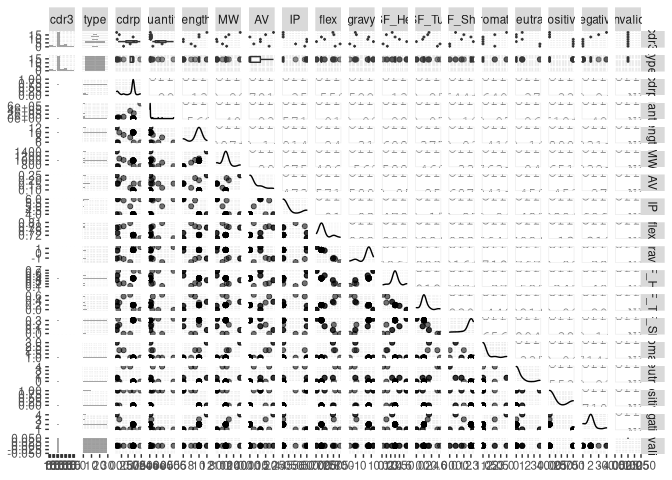

```r
cdr %>%
        ungroup() %>%
        arrange(-cdrp, type, file) %>%
        filter(quantity > 1) %>%
        filter(type == "final") -> cdr_final

cdr_final %>%
                filter(quantity > 1) %>%
                group_by(file) %>%
                slice_head(n = 1) -> cdr_enriched

library(GGally)
cdr_enriched %<>%
                select(cdr3:SSF_Sheet, aromatic:file)

cdr_enriched %>%
                ungroup() %>%
                select(-file) %>%
                ggpairs(aes(alpha = 0.4))
```

```r
cdr_final %>%
             ungroup() %>%
             select(!c(cdr3, type, file, invalid)) -> cdr_final_pca

pca_result <- prcomp(cdr_final_pca, center = T, scale. = T)
summary(pca_result)
```

```
## Importance of components:
##                           PC1    PC2     PC3     PC4     PC5    PC6     PC7
## Standard deviation     2.2320 2.1424 1.82898 1.61396 1.52117 1.3145 1.22483
## Proportion of Variance 0.1384 0.1275 0.09292 0.07236 0.06428 0.0480 0.04167
## Cumulative Proportion  0.1384 0.2659 0.35881 0.43117 0.49544 0.5434 0.58511
##                            PC8     PC9   PC10    PC11   PC12    PC13    PC14
## Standard deviation     1.20982 1.12969 1.1144 1.05725 1.0462 0.98564 0.98080
## Proportion of Variance 0.04066 0.03545 0.0345 0.03105 0.0304 0.02699 0.02672
## Cumulative Proportion  0.62577 0.66122 0.6957 0.72677 0.7572 0.78416 0.81088
##                           PC15    PC16   PC17    PC18    PC19    PC20    PC21
## Standard deviation     0.97047 0.95699 0.9431 0.90463 0.86672 0.86159 0.81767
## Proportion of Variance 0.02616 0.02544 0.0247 0.02273 0.02087 0.02062 0.01857
## Cumulative Proportion  0.83704 0.86248 0.8872 0.90991 0.93078 0.95140 0.96997
##                           PC22    PC23    PC24    PC25    PC26    PC27   PC28
## Standard deviation     0.72682 0.43550 0.34254 0.32517 0.26219 0.20040 0.1465
## Proportion of Variance 0.01467 0.00527 0.00326 0.00294 0.00191 0.00112 0.0006
## Cumulative Proportion  0.98465 0.98992 0.99318 0.99611 0.99802 0.99914 0.9997
##                           PC29     PC30      PC31      PC32      PC33      PC34
## Standard deviation     0.09783 1.62e-14 5.817e-15 5.189e-15 4.404e-15 3.802e-15
## Proportion of Variance 0.00027 0.00e+00 0.000e+00 0.000e+00 0.000e+00 0.000e+00
## Cumulative Proportion  1.00000 1.00e+00 1.000e+00 1.000e+00 1.000e+00 1.000e+00
##                             PC35      PC36
## Standard deviation     3.541e-15 2.381e-15
## Proportion of Variance 0.000e+00 0.000e+00
## Cumulative Proportion  1.000e+00 1.000e+00
```

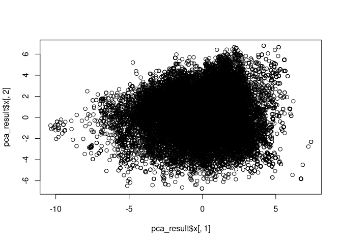

```r
plot(pca_result$x[,1], pca_result$x[,2])
```

```r
cdr_final_pca
```

```
## # A tibble: 30,818 x 36
##     cdrp quantity length    MW    AV    IP  flex gravy SSF_Helix SSF_Turn
##    <dbl>    <int>  <int> <dbl> <dbl> <dbl> <dbl> <dbl>     <dbl>    <dbl>
##  1 0.963   714166      6  734. 0.167  6.00 0.702  1.27     0.667      0
##  2 0.716   254505      6  734. 0.167  6.00 0.702  1.27     0.667      0
##  3 0.703     6481     10  979. 0.1    4.05 0.723  0.67     0.4        0.2
##  4 0.703     6481     10  979. 0.1    4.05 0.723  0.67     0.4        0.2
##  5 0.703     6481     10  979. 0.1    4.05 0.723  0.67     0.4        0.2
##  6 0.703     6481     10  979. 0.1    4.05 0.723  0.67     0.4        0.2
##  7 0.696    11866     10  979. 0.1    4.05 0.723  0.67     0.4        0.2
##  8 0.696    11866     10  979. 0.1    4.05 0.723  0.67     0.4        0.2
##  9 0.696    11866     10  979. 0.1    4.05 0.723  0.67     0.4        0.2
## 10 0.696    11866     10  979. 0.1    4.05 0.723  0.67     0.4        0.2
## # … with 30,808 more rows, and 26 more variables: SSF_Sheet <dbl>, n_A <int>,
## #   n_C <int>, n_D <int>, n_E <int>, n_F <int>, n_G <int>, n_H <int>,
## #   n_I <int>, n_K <int>, n_L <int>, n_M <int>, n_N <int>, n_P <int>,
## #   n_Q <int>, n_R <int>, n_S <int>, n_T <int>, n_V <int>, n_W <int>,
## #   n_Y <int>, aliphatic <int>, aromatic <int>, neutral <int>, positive <int>,
## #   negative <int>
```

```r
cdr_final %>%
              group_by(file) %>%
              arrange(-cdrp) %>%
              slice_head(n = 1) %>%
              ungroup() %>%
              select(!c(cdr3, type, file, invalid)) %>%
              arrange(-cdrp) -> a

# in this line we remove all collumns that have variance equal to 0
# Doing this, we can apply a pca to the dataframe without erros
# credit goes to: https://stackoverflow.com/a/40317343
a <- select(a, !c(which(apply(a, 2, var)==0)))
pca_a <- prcomp(a, center = T, scale. = T)
summary(pca_a)
```

```
## Importance of components:
##                          PC1    PC2    PC3     PC4     PC5    PC6     PC7
## Standard deviation     3.578 3.1940 2.0814 1.42383 1.19178 0.9347 0.56375
## Proportion of Variance 0.400 0.3188 0.1354 0.06335 0.04439 0.0273 0.00993
## Cumulative Proportion  0.400 0.7188 0.8542 0.91753 0.96192 0.9892 0.99915
##                            PC8      PC9      PC10      PC11      PC12      PC13
## Standard deviation     0.16506 1.82e-15 2.891e-16 2.891e-16 2.891e-16 2.891e-16
## Proportion of Variance 0.00085 0.00e+00 0.000e+00 0.000e+00 0.000e+00 0.000e+00
## Cumulative Proportion  1.00000 1.00e+00 1.000e+00 1.000e+00 1.000e+00 1.000e+00
##                             PC14      PC15      PC16      PC17      PC18
## Standard deviation     2.891e-16 2.891e-16 2.891e-16 2.891e-16 2.891e-16
## Proportion of Variance 0.000e+00 0.000e+00 0.000e+00 0.000e+00 0.000e+00
## Cumulative Proportion  1.000e+00 1.000e+00 1.000e+00 1.000e+00 1.000e+00
##                             PC19      PC20      PC21      PC22      PC23
## Standard deviation     2.891e-16 2.891e-16 2.891e-16 2.891e-16 2.891e-16
## Proportion of Variance 0.000e+00 0.000e+00 0.000e+00 0.000e+00 0.000e+00
## Cumulative Proportion  1.000e+00 1.000e+00 1.000e+00 1.000e+00 1.000e+00
##                             PC24      PC25      PC26      PC27      PC28
## Standard deviation     2.891e-16 2.891e-16 2.891e-16 2.891e-16 2.891e-16
## Proportion of Variance 0.000e+00 0.000e+00 0.000e+00 0.000e+00 0.000e+00
## Cumulative Proportion  1.000e+00 1.000e+00 1.000e+00 1.000e+00 1.000e+00
##                             PC29
## Standard deviation     2.891e-16
## Proportion of Variance 0.000e+00
## Cumulative Proportion  1.000e+00
```

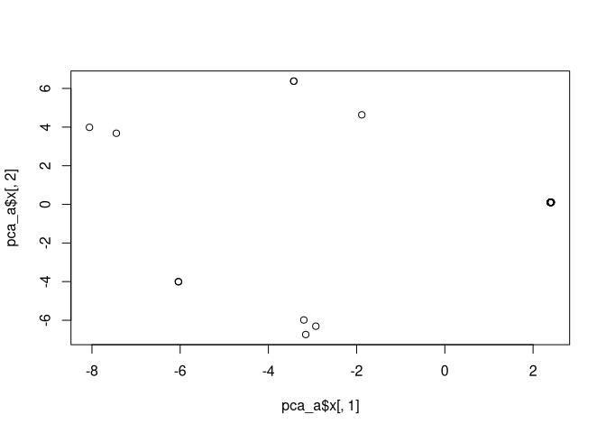

```r
plot(pca_a$x[,1], pca_a$x[,2])
```

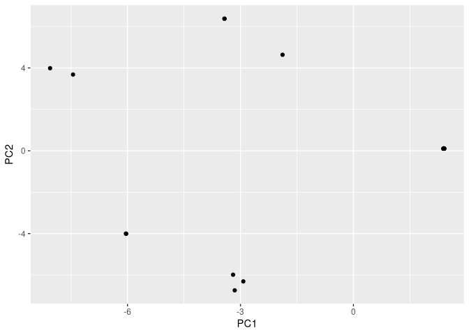

```r
ggplot(as_tibble(pca_a$x)) +
  geom_point(aes(PC1, PC2))
```

```r
pca_a$x
```

```
##             PC1        PC2        PC3         PC4         PC5         PC6
##  [1,] -3.153187 -6.7396691  0.5423173  2.02558876 -3.16509933  1.12651448
##  [2,] -2.924818 -6.3081964  1.1150958  1.00898751 -1.56987430  0.22477835
##  [3,]  2.410307  0.1050559 -0.4026319 -0.12398379  0.07212154 -0.09425090
##  [4,]  2.410307  0.1050559 -0.4026319 -0.12398379  0.07212154 -0.09425090
##  [5,]  2.410307  0.1050559 -0.4026319 -0.12398379  0.07212154 -0.09425090
##  [6,]  2.410307  0.1050559 -0.4026319 -0.12398379  0.07212154 -0.09425090
##  [7,]  2.400501  0.1030796 -0.4000082 -0.11578167  0.06524087 -0.08679969
##  [8,]  2.400501  0.1030796 -0.4000082 -0.11578167  0.06524087 -0.08679969
##  [9,]  2.400501  0.1030796 -0.4000082 -0.11578167  0.06524087 -0.08679969
## [10,]  2.400501  0.1030796 -0.4000082 -0.11578167  0.06524087 -0.08679969
## [11,]  2.395003  0.1023694 -0.3978832 -0.11203533  0.06286417 -0.08337386
## [12,]  2.395003  0.1023694 -0.3978832 -0.11203533  0.06286417 -0.08337386
## [13,]  2.395003  0.1023694 -0.3978832 -0.11203533  0.06286417 -0.08337386
## [14,]  2.395003  0.1023694 -0.3978832 -0.11203533  0.06286417 -0.08337386
```

[output cut: 165 more lines]

```r
str(pca_a)
```

```
## List of 5
##  $ sdev    : num [1:29] 3.58 3.19 2.08 1.42 1.19 ...
##  $ rotation: num [1:32, 1:29] 0.186 -0.131 0.157 0.054 -0.215 ...
##   ..- attr(*, "dimnames")=List of 2
##   .. ..$ : chr [1:32] "cdrp" "quantity" "length" "MW" ...
##   .. ..$ : chr [1:29] "PC1" "PC2" "PC3" "PC4" ...
##  $ center  : Named num [1:32] 5.64e-01 6.42e+04 9.34 9.65e+02 1.30e-01 ...
##   ..- attr(*, "names")= chr [1:32] "cdrp" "quantity" "length" "MW" ...
##  $ scale   : Named num [1:32] 2.58e-01 1.48e+05 1.70 1.53e+02 4.86e-02 ...
##   ..- attr(*, "names")= chr [1:32] "cdrp" "quantity" "length" "MW" ...
##  $ x       : num [1:29, 1:29] -3.15 -2.92 2.41 2.41 2.41 ...
##   ..- attr(*, "dimnames")=List of 2
##   .. ..$ : NULL
##   .. ..$ : chr [1:29] "PC1" "PC2" "PC3" "PC4" ...
##  - attr(*, "class")= chr "prcomp"
```

```r
pca_cdr_result <- cdr %>%
                        select(!c(cdr3, type, file, invalid)) %>%
                        prcomp(center = T, scale. = T)
summary(pca_cdr_result)
```

```
## Importance of components:
##                           PC1    PC2     PC3     PC4     PC5     PC6     PC7
## Standard deviation     2.2070 2.0517 1.83300 1.61745 1.57126 1.26983 1.25221
## Proportion of Variance 0.1353 0.1169 0.09333 0.07267 0.06858 0.04479 0.04356
## Cumulative Proportion  0.1353 0.2522 0.34556 0.41823 0.48681 0.53160 0.57516
##                           PC8     PC9    PC10    PC11    PC12    PC13    PC14
## Standard deviation     1.1940 1.17812 1.07633 1.03880 1.02983 1.01582 1.00061
## Proportion of Variance 0.0396 0.03855 0.03218 0.02997 0.02946 0.02866 0.02781
## Cumulative Proportion  0.6148 0.65331 0.68549 0.71547 0.74493 0.77359 0.80140
##                           PC15    PC16    PC17    PC18    PC19    PC20    PC21
## Standard deviation     0.99209 0.98029 0.95983 0.95470 0.90047 0.87291 0.85869
## Proportion of Variance 0.02734 0.02669 0.02559 0.02532 0.02252 0.02117 0.02048
## Cumulative Proportion  0.82874 0.85544 0.88103 0.90635 0.92887 0.95003 0.97052
##                           PC22    PC23    PC24    PC25    PC26    PC27    PC28
## Standard deviation     0.75771 0.44052 0.30147 0.29571 0.24285 0.18264 0.12589
## Proportion of Variance 0.01595 0.00539 0.00252 0.00243 0.00164 0.00093 0.00044
## Cumulative Proportion  0.98646 0.99185 0.99438 0.99681 0.99845 0.99937 0.99981
##                           PC29      PC30      PC31     PC32      PC33     PC34
## Standard deviation     0.08195 1.326e-12 8.635e-14 6.31e-14 6.009e-14 3.98e-14
## Proportion of Variance 0.00019 0.000e+00 0.000e+00 0.00e+00 0.000e+00 0.00e+00
## Cumulative Proportion  1.00000 1.000e+00 1.000e+00 1.00e+00 1.000e+00 1.00e+00
##                             PC35      PC36
## Standard deviation     2.841e-14 1.485e-14
## Proportion of Variance 0.000e+00 0.000e+00
## Cumulative Proportion  1.000e+00 1.000e+00
```

```r
cdr_final %>%
              group_by(file) %>%
              arrange(-cdrp) %>%
              slice_head(n = 10) %>%
              ungroup() %>%
              select(!c(cdr3, type, file, invalid)) %>%
              arrange(-cdrp) -> b

b <- select(b, !c(which(apply(b, 2, var)==0)))
b
```

```
## # A tibble: 290 x 36
##     cdrp quantity length    MW    AV    IP  flex gravy SSF_Helix SSF_Turn
##    <dbl>    <int>  <int> <dbl> <dbl> <dbl> <dbl> <dbl>     <dbl>    <dbl>
##  1 0.963   714166      6  734. 0.167  6.00 0.702  1.27     0.667      0
##  2 0.716   254505      6  734. 0.167  6.00 0.702  1.27     0.667      0
##  3 0.703     6481     10  979. 0.1    4.05 0.723  0.67     0.4        0.2
##  4 0.703     6481     10  979. 0.1    4.05 0.723  0.67     0.4        0.2
##  5 0.703     6481     10  979. 0.1    4.05 0.723  0.67     0.4        0.2
##  6 0.703     6481     10  979. 0.1    4.05 0.723  0.67     0.4        0.2
##  7 0.696    11866     10  979. 0.1    4.05 0.723  0.67     0.4        0.2
##  8 0.696    11866     10  979. 0.1    4.05 0.723  0.67     0.4        0.2
##  9 0.696    11866     10  979. 0.1    4.05 0.723  0.67     0.4        0.2
## 10 0.696    11866     10  979. 0.1    4.05 0.723  0.67     0.4        0.2
## # … with 280 more rows, and 26 more variables: SSF_Sheet <dbl>, n_A <int>,
## #   n_C <int>, n_D <int>, n_E <int>, n_F <int>, n_G <int>, n_H <int>,
## #   n_I <int>, n_K <int>, n_L <int>, n_M <int>, n_N <int>, n_P <int>,
## #   n_Q <int>, n_R <int>, n_S <int>, n_T <int>, n_V <int>, n_W <int>,
## #   n_Y <int>, aliphatic <int>, aromatic <int>, neutral <int>, positive <int>,
## #   negative <int>
```

```r
pca_b <- prcomp(b, center = T, scale. = T)
summary(pca_b)
```

```
## Importance of components:
##                           PC1    PC2    PC3    PC4     PC5     PC6     PC7
## Standard deviation     2.9161 2.4665 1.9498 1.7410 1.52362 1.35730 1.26191
## Proportion of Variance 0.2362 0.1690 0.1056 0.0842 0.06448 0.05117 0.04423
## Cumulative Proportion  0.2362 0.4052 0.5108 0.5950 0.65949 0.71066 0.75490
##                            PC8     PC9    PC10    PC11    PC12    PC13   PC14
## Standard deviation     1.14684 1.07537 1.04875 0.97586 0.82782 0.79248 0.7074
## Proportion of Variance 0.03653 0.03212 0.03055 0.02645 0.01904 0.01745 0.0139
## Cumulative Proportion  0.79143 0.82355 0.85411 0.88056 0.89959 0.91704 0.9309
##                           PC15    PC16    PC17   PC18    PC19    PC20   PC21
## Standard deviation     0.66953 0.63727 0.57337 0.5629 0.50397 0.45910 0.3981
## Proportion of Variance 0.01245 0.01128 0.00913 0.0088 0.00706 0.00585 0.0044
## Cumulative Proportion  0.94339 0.95467 0.96381 0.9726 0.97966 0.98552 0.9899
##                           PC22    PC23    PC24    PC25    PC26    PC27    PC28
## Standard deviation     0.38050 0.30999 0.23902 0.17910 0.12711 0.09736 0.07041
## Proportion of Variance 0.00402 0.00267 0.00159 0.00089 0.00045 0.00026 0.00014
## Cumulative Proportion  0.99394 0.99661 0.99820 0.99909 0.99954 0.99980 0.99994
##                           PC29      PC30      PC31      PC32      PC33
## Standard deviation     0.04712 1.566e-15 9.467e-16 8.825e-16 6.685e-16
## Proportion of Variance 0.00006 0.000e+00 0.000e+00 0.000e+00 0.000e+00
## Cumulative Proportion  1.00000 1.000e+00 1.000e+00 1.000e+00 1.000e+00
##                             PC34      PC35      PC36
## Standard deviation     4.817e-16 4.617e-16 2.517e-16
## Proportion of Variance 0.000e+00 0.000e+00 0.000e+00
## Cumulative Proportion  1.000e+00 1.000e+00 1.000e+00
```

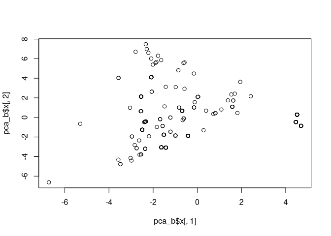

```r
plot(pca_b$x[,1], pca_b$x[,2])
```

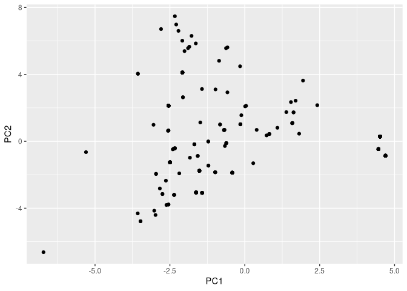

```r
ggplot(as_tibble(pca_b$x)) +
  geom_point(aes(PC1, PC2))
```

```r
summary(pca_b)
```

```
## Importance of components:
##                           PC1    PC2    PC3    PC4     PC5     PC6     PC7
## Standard deviation     2.9161 2.4665 1.9498 1.7410 1.52362 1.35730 1.26191
## Proportion of Variance 0.2362 0.1690 0.1056 0.0842 0.06448 0.05117 0.04423
## Cumulative Proportion  0.2362 0.4052 0.5108 0.5950 0.65949 0.71066 0.75490
##                            PC8     PC9    PC10    PC11    PC12    PC13   PC14
## Standard deviation     1.14684 1.07537 1.04875 0.97586 0.82782 0.79248 0.7074
## Proportion of Variance 0.03653 0.03212 0.03055 0.02645 0.01904 0.01745 0.0139
## Cumulative Proportion  0.79143 0.82355 0.85411 0.88056 0.89959 0.91704 0.9309
##                           PC15    PC16    PC17   PC18    PC19    PC20   PC21
## Standard deviation     0.66953 0.63727 0.57337 0.5629 0.50397 0.45910 0.3981
## Proportion of Variance 0.01245 0.01128 0.00913 0.0088 0.00706 0.00585 0.0044
## Cumulative Proportion  0.94339 0.95467 0.96381 0.9726 0.97966 0.98552 0.9899
##                           PC22    PC23    PC24    PC25    PC26    PC27    PC28
## Standard deviation     0.38050 0.30999 0.23902 0.17910 0.12711 0.09736 0.07041
## Proportion of Variance 0.00402 0.00267 0.00159 0.00089 0.00045 0.00026 0.00014
## Cumulative Proportion  0.99394 0.99661 0.99820 0.99909 0.99954 0.99980 0.99994
##                           PC29      PC30      PC31      PC32      PC33
## Standard deviation     0.04712 1.566e-15 9.467e-16 8.825e-16 6.685e-16
## Proportion of Variance 0.00006 0.000e+00 0.000e+00 0.000e+00 0.000e+00
## Cumulative Proportion  1.00000 1.000e+00 1.000e+00 1.000e+00 1.000e+00
##                             PC34      PC35      PC36
## Standard deviation     4.817e-16 4.617e-16 2.517e-16
## Proportion of Variance 0.000e+00 0.000e+00 0.000e+00
## Cumulative Proportion  1.000e+00 1.000e+00 1.000e+00
```

```r
summary(cdr$quantity)
```

```
##     Min.  1st Qu.   Median     Mean  3rd Qu.     Max.
##      1.0      1.0      1.0     10.8      4.0 714166.0
```

```r
cdr %>%
        filter(quantity >= 100) -> a
a
```

```
## # A tibble: 5,027 x 40
##    cdr3  type   cdrp quantity length    MW    AV    IP  flex gravy SSF_Helix
##    <chr> <fct> <dbl>    <int>  <int> <dbl> <dbl> <dbl> <dbl> <dbl>     <dbl>
##  1 FLVE… final 0.963   714166      6  734. 0.167  6.00 0.702  1.27     0.667
##  2 FLVE… final 0.716   254505      6  734. 0.167  6.00 0.702  1.27     0.667
##  3 DGVA… final 0.703     6481     10  979. 0.1    4.05 0.723  0.67     0.4
##  4 DGVA… final 0.703     6481     10  979. 0.1    4.05 0.723  0.67     0.4
##  5 DGVA… final 0.703     6481     10  979. 0.1    4.05 0.723  0.67     0.4
##  6 DGVA… final 0.703     6481     10  979. 0.1    4.05 0.723  0.67     0.4
##  7 DGVA… final 0.696    11866     10  979. 0.1    4.05 0.723  0.67     0.4
##  8 DGVA… final 0.696    11866     10  979. 0.1    4.05 0.723  0.67     0.4
##  9 DGVA… final 0.696    11866     10  979. 0.1    4.05 0.723  0.67     0.4
## 10 DGVA… final 0.696    11866     10  979. 0.1    4.05 0.723  0.67     0.4
## # … with 5,017 more rows, and 29 more variables: SSF_Turn <dbl>,
## #   SSF_Sheet <dbl>, n_A <int>, n_C <int>, n_D <int>, n_E <int>, n_F <int>,
## #   n_G <int>, n_H <int>, n_I <int>, n_K <int>, n_L <int>, n_M <int>,
## #   n_N <int>, n_P <int>, n_Q <int>, n_R <int>, n_S <int>, n_T <int>,
## #   n_V <int>, n_W <int>, n_Y <int>, aliphatic <int>, aromatic <int>,
## #   neutral <int>, positive <int>, negative <int>, invalid <int>, file <chr>
```

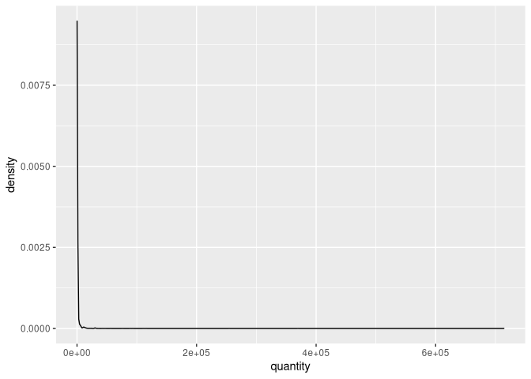

```r
ggplot(a) +
  geom_density(aes(quantity))
```

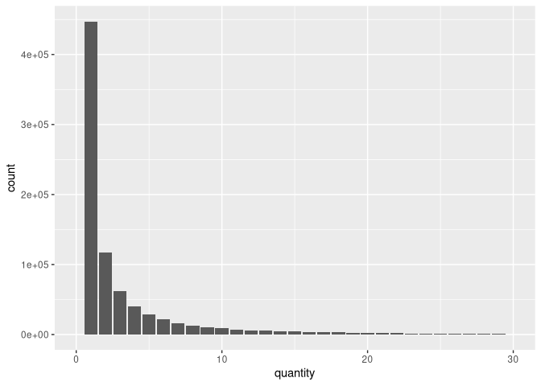

```r
ggplot(cdr) +
  geom_bar(aes(quantity)) +
  xlim(0, 30)
```

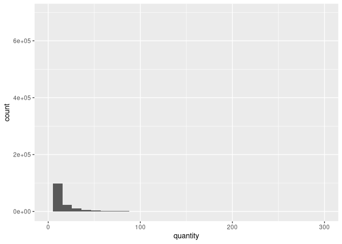

```r
ggplot(cdr) +
  geom_histogram(aes(quantity)) +
  xlim(0, 300)
```

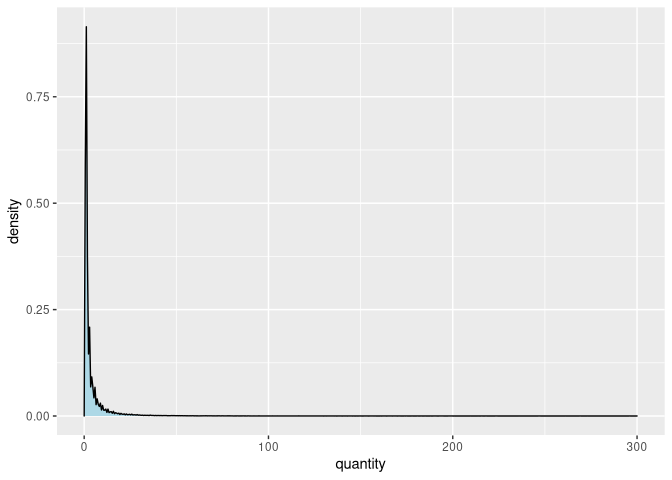

```r
ggplot(cdr) +
  geom_density(aes(quantity), fill = "lightblue") +
  xlim(0, 300)
```

```r
quantile(cdr$quantity)
```

```
##     0%    25%    50%    75%   100%
##      1      1      1      4 714166
```

```r
dim(cdr)
```

```
## [1] 846376     40
```

```r
cdr %>% filter(quantity >= 1E3) %>% dim()
```

```
## [1] 555  40
```

```r
cdr %>% filter(quantity >= 1E4) %>% dim()
```

```
## [1] 87 40
```

```r
cdr %>% filter(quantity >= 1E5) %>% dim()
```

```
## [1]  5 40
```

```r
cdr %>% filter(quantity >= 1E3) -> b
b %>% group_by(type) %>% summarise(total = n())
```

```
## # A tibble: 2 x 2
##   type    total
##   <fct>   <int>
## 1 final     299
## 2 initial   256
```

```r
b %>% group_by(type) %>% summarise(quantile = quantile(cdrp)) -> b_quantiles
b_quantiles <- add_column(b_quantiles, quantiles = rep(attr(quantile(b$quantity), "names"), 2))
knitr::kable(b_quantiles)
```

| type | quantile | quantiles |
| --- | --- | --- |
| final | 0.0013875 | 0% |
| final | 0.0044044 | 25% |
| final | 0.0093961 | 50% |
| final | 0.0336626 | 75% |
| final | 0.9629992 | 100% |
| initial | 0.0028332 | 0% |
| initial | 0.0038802 | 25% |
| initial | 0.0074028 | 50% |
| initial | 0.0224001 | 75% |
| initial | 0.0972894 | 100% |